# H09 Stage 2: implementation, diagnostics, and V0 comparison

Chronotype and timing of personal light exposure — author result gate

Published

August 10, 2026

**NoteStage 2 gate closed — approved as amended**

This document reports the author-approved H09 implementation, exact fitted samples, 95% confidence intervals, four complete five-outcome multiplicity families, interpreted diagnostics, V0 reconciliation, and planned sensitivities. Under decision H09-002 (2026-08-10), the author accepted the result gates and judged the response/residual distributions and residual heteroscedasticity acceptable after visually inspecting Figures 2 and 3. The quantitative screen flags remain visible in the audit artifacts. This report reads frozen H09 artifacts and does not refit models. No bootstrap, simulation, or other resampling was run, so the pilot/production resampling gate was not needed. The standalone reader report is authorized.

# 1 Hypothesis, constructs, and estimand

The signed preregistration states:

> **H9: Timing-based metrics are associated with chronotype (MCTQ, MEQ).**

H09 asks whether participant-level chronotype is associated with the local clock timing of personal light exposure across participant-days. MCTQ `MSFsc` and MEQ remain separate registered constructs. A positive MCTQ coefficient means later corrected midsleep is associated with later exposure timing. A negative MEQ coefficient means that greater morning preference is associated with earlier exposure timing. These are between-participant, site-adjusted associations, not within-person day-to-day or causal effects.

Near-eye evidence is primary and chest evidence complementary. Placements are not pooled. The **gap-timing-unaware dataset** is the dataset applying the 50%-per-hour and 80%-per-day coverage rules but not using the remaining gaps’ time of day in metric-specific support decisions. This contrasts with the time-sensitive primary dataset; below it is called simply the primary dataset.

# 2 Frozen implementation contract

## 2.1 Stage 1 approvals and input identity

Frozen Stage 2 authorization and identity checks

| Check | Result |
| --- | --- |
| Stage 1 gates approved | 16 / 16 |
| H09-G4 aggregate-score decision | Pinned aggregate calculated fields msf_sc and meq explicitly accepted |
| Pinned analytical inputs | 16 / 16 hashes and row contracts verified |
| Preparation 06 input bundle | Identity verified |
| R runtime | R 4.6.1 |
| Production resampling | NOT NEEDED; no bootstrap or simulation run |

H09-G4 explicitly accepts the pinned aggregate calculated fields msf_sc and meq. PREP-003/FIND-044 remains a declared shared-provenance qualification; PREP06-BASE-002 authorizes the current bundle for this gated analysis.

H09-G4 explicitly accepts the pinned aggregate calculated fields `msf_sc` for MCTQ and `meq` for MEQ. Item-level questionnaire responses and an independent scoring reconstruction are unavailable, so the acceptance applies to these exact aggregate values and does not establish item-level scoring validity. The source-to-normalized value audit matched every available value.

Pinned MCTQ and MEQ aggregates

| Participants | Sites | MCTQ complete / missing | MCTQ range, h | MCTQ centre, h | MEQ complete / missing | MEQ range | MEQ centre | Item-level reconstruction |
| --- | --- | --- | --- | --- | --- | --- | --- | --- |
| 186 | 9 | 185 / 1 | 1.26–8.13 | 4.113584298583480 | 186 / 0 | 28–73 | 52.86021505376344 | Unavailable |

MCTQ effects are per one-hour later MSFsc. MEQ effects are per 10 score points greater morning preference. Fixed global centres are used for every placement, metric, and sensitivity.

## 2.2 Exact fitted models

The primary Gaussian identity-link mixed models use submitted-site sum contrasts and a random intercept for participant nested in site. The site-only model and site-plus-chronotype model are compared by maximum-likelihood LRT for the main association; the additive and site-interaction models are compared separately. Estimates and Wald 95% confidence intervals come from the REML site-plus-chronotype model. No outcome-selected model is reported.

```r
MCTQ_M0 <- stats::as.formula(
  "timing_hour ~ site + (1 | site:Id)"
)
MCTQ_M1 <- stats::as.formula(
  "timing_hour ~ site + mctq_hour_centered + (1 | site:Id)"
)
MCTQ_M2 <- stats::as.formula(
  "timing_hour ~ site * mctq_hour_centered + (1 | site:Id)"
)
MEQ_M0 <- stats::as.formula(
  "timing_hour ~ site + (1 | site:Id)"
)
MEQ_M1 <- stats::as.formula(
  "timing_hour ~ site + meq_10_centered + (1 | site:Id)"
)
MEQ_M2 <- stats::as.formula(
  "timing_hour ~ site * meq_10_centered + (1 | site:Id)"
)

list(
  MCTQ_M0 = MCTQ_M0,
  MCTQ_M1 = MCTQ_M1,
  MCTQ_M2 = MCTQ_M2,
  MEQ_M0 = MEQ_M0,
  MEQ_M1 = MEQ_M1,
  MEQ_M2 = MEQ_M2
)
```

```
$MCTQ_M0
timing_hour ~ site + (1 | site:Id)

$MCTQ_M1
timing_hour ~ site + mctq_hour_centered + (1 | site:Id)

$MCTQ_M2
timing_hour ~ site * mctq_hour_centered + (1 | site:Id)

$MEQ_M0
timing_hour ~ site + (1 | site:Id)

$MEQ_M1
timing_hour ~ site + meq_10_centered + (1 | site:Id)

$MEQ_M2
timing_hour ~ site * meq_10_centered + (1 | site:Id)
```

The complete formula registry also records the spline-linearity, within-site-centred photoperiod, participant-summary, continuous-time AR(1), and V0 formulas supplied to their respective R functions.

Complete evaluated H09 formula registry

| Analysis | Instrument | Formula / structure | Wilkinson |
| --- | --- | --- | --- |
| Approved participant day | MCTQ | M0_site_only | `timing_hour ~ site + (1 \| site:Id)` |
| Approved participant day | MCTQ | M1_main | `timing_hour ~ site + mctq_hour_centered + (1 \| site:Id)` |
| Approved participant day | MCTQ | M2_interaction | `timing_hour ~ site * mctq_hour_centered + (1 \| site:Id)` |
| Approved participant day | MCTQ | D_spline | `timing_hour ~ site + splines::ns(mctq_hour_centered, df = 3) + (1 \| site:Id)` |
| Approved participant day | MEQ | M0_site_only | `timing_hour ~ site + (1 \| site:Id)` |
| Approved participant day | MEQ | M1_main | `timing_hour ~ site + meq_10_centered + (1 \| site:Id)` |
| Approved participant day | MEQ | M2_interaction | `timing_hour ~ site * meq_10_centered + (1 \| site:Id)` |
| Approved participant day | MEQ | D_spline | `timing_hour ~ site + splines::ns(meq_10_centered, df = 3) + (1 \| site:Id)` |
| Photoperiod sensitivity | MCTQ | P0_site_photoperiod | `timing_hour ~ site + photoperiod_within_site + (1 \| site:Id)` |
| Photoperiod sensitivity | MCTQ | P1_main | `timing_hour ~ site + photoperiod_within_site + mctq_hour_centered + (1 \| site:Id)` |
| Photoperiod sensitivity | MCTQ | P2_interaction | `timing_hour ~ site * mctq_hour_centered + photoperiod_within_site + (1 \| site:Id)` |
| Photoperiod sensitivity | MEQ | P0_site_photoperiod | `timing_hour ~ site + photoperiod_within_site + (1 \| site:Id)` |
| Photoperiod sensitivity | MEQ | P1_main | `timing_hour ~ site + photoperiod_within_site + meq_10_centered + (1 \| site:Id)` |
| Photoperiod sensitivity | MEQ | P2_interaction | `timing_hour ~ site * meq_10_centered + photoperiod_within_site + (1 \| site:Id)` |
| Participant summary sensitivity | MCTQ | S0_site_only | `participant_mean_timing_hour ~ site` |
| Participant summary sensitivity | MCTQ | S1_main | `participant_mean_timing_hour ~ site + mctq_hour_centered` |
| Participant summary sensitivity | MCTQ | S2_interaction | `participant_mean_timing_hour ~ site * mctq_hour_centered` |
| Participant summary sensitivity | MEQ | S0_site_only | `participant_mean_timing_hour ~ site` |
| Participant summary sensitivity | MEQ | S1_main | `participant_mean_timing_hour ~ site + meq_10_centered` |
| Participant summary sensitivity | MEQ | S2_interaction | `participant_mean_timing_hour ~ site * meq_10_centered` |
| Continuous time ar1 sensitivity | MCTQ | fixed | `timing_hour ~ site + mctq_hour_centered` |
| Continuous time ar1 sensitivity | MCTQ | random | `~1 \| participant_key` |
| Continuous time ar1 sensitivity | MCTQ | correlation | `~elapsed_day \| participant_key` |
| Continuous time ar1 sensitivity | MEQ | fixed | `timing_hour ~ site + meq_10_centered` |
| Continuous time ar1 sensitivity | MEQ | random | `~1 \| participant_key` |
| Continuous time ar1 sensitivity | MEQ | correlation | `~elapsed_day \| participant_key` |
| V0 reconstruction | MCTQ | H9_1 | `timing_hour ~ site * mctq_hour + (1 \| Id)` |
| V0 reconstruction | MCTQ | H9_0 | `timing_hour ~ site + (1 \| Id)` |
| V0 reconstruction | MCTQ | H9_00 | `timing_hour ~ 1 + (1 \| Id)` |
| V0 reconstruction | MCTQ | H9_ni | `timing_hour ~ site + mctq_hour + (1 \| Id)` |
| V0 reconstruction | MCTQ | H9_ns | `timing_hour ~ mctq_hour + (1 \| Id)` |

## 2.3 Outcomes, clocks, and multiplicity

The five registered outcomes are M10 midpoint, L10 midpoint, first and last timing above 250 lx melEDI, and the exact-identifiable midpoint of the selected longest continuous period above 250 lx melEDI. Mean timing above 250 lx melEDI is retained as the named adapted alternative and is outside H09-F1–F4. Clock responses are linearized only where their observed support permits it. L10 uses the registered strict `>16:00` negative-hour conversion; onset and offset variants of M10/L10 are excluded.

Timing-outcome contract

| Order | Metric | Branch | Unit | Definition |
| --- | --- | --- | --- | --- |
| 1 | Midpoint of the brightest 10 hours | Registered five-outcome family member | local clock hour | Local midpoint of the brightest supported 10 hours |
| 2 | Midpoint of the darkest 10 hours | Registered five-outcome family member | local clock hour | Local midpoint of the darkest supported 10 hours; strict >16:00 values shifted by -24 hours |
| 3 | First light timing above 250 lx melEDI | Registered five-outcome family member | local clock hour | First supported local timing above 250 lx melEDI |
| 4 | Last light timing above 250 lx melEDI | Registered five-outcome family member | local clock hour | Last supported local timing above 250 lx melEDI |
| 5 | Midpoint of the longest continuous period above 250 lx melEDI | Registered five-outcome family member | local clock hour | Local midpoint of the selected longest continuous period above 250 lx melEDI, restricted to exact-identifiable periods |
| 6 | Mean timing of exposure above 250 lx melEDI | Adapted sensitivity outside F1–F4 | local clock hour | Duration-weighted mean local timing across supported exposure above 250 lx melEDI |

There are four separately labelled five-member BH families: MCTQ main effects (H09-F1), MEQ main effects (H09-F2), MCTQ-by-site interactions (H09-F3), and MEQ-by-site interactions (H09-F4). Site-specific slopes are descriptive; the 90-member H09-F5 family was not activated. Significance was determined from the unrounded values before display. In the result tables, raw p-values are bold when raw `p < 0.05`; BH values are bold only when adjusted `p < 0.05` in the explicitly named five-member family. Scientific conclusions use the BH rule.

# 3 Exact fitted samples

Every participant-day model used one observation per participant-day. Derivation hours sum the supported hours feeding the outcome in that exact frame. MCTQ has one missing participant-level value; consequently its fitted samples are usually one participant and several participant-days smaller than MEQ samples. Longest-period samples are smaller because only exact-identifiable selected periods are admissible.

Exact primary-dataset all-available fitted samples

| Placement | Metric | Instrument | Participants | Participant-days | Observations | Derivation hours | Sites | Days/participant |
| --- | --- | --- | --- | --- | --- | --- | --- | --- |
| Chest | M10 midpoint | MCTQ MSFsc | 153 | 896 | 896 | 20752.4 | 8 | 2–8 (median 6) |
| Chest | M10 midpoint | MEQ | 154 | 902 | 902 | 20891.8 | 8 | 2–8 (median 6) |
| Chest | L10 midpoint | MCTQ MSFsc | 153 | 896 | 896 | 20752.4 | 8 | 2–8 (median 6) |
| Chest | L10 midpoint | MEQ | 154 | 902 | 902 | 20891.8 | 8 | 2–8 (median 6) |
| Chest | First >250 | MCTQ MSFsc | 153 | 797 | 797 | 18518.4 | 8 | 1–7 (median 6) |
| Chest | First >250 | MEQ | 154 | 802 | 802 | 18634.7 | 8 | 1–7 (median 6) |
| Chest | Last >250 | MCTQ MSFsc | 153 | 783 | 783 | 18263.8 | 8 | 2–7 (median 5) |
| Chest | Last >250 | MEQ | 154 | 787 | 787 | 18358.1 | 8 | 2–7 (median 5) |
| Chest | Longest-period midpoint | MCTQ MSFsc | 149 | 547 | 547 | 12980.0 | 8 | 1–7 (median 4) |
| Chest | Longest-period midpoint | MEQ | 150 | 549 | 549 | 13027.8 | 8 | 1–7 (median 4) |
| Chest | Mean >250 | MCTQ MSFsc | 153 | 825 | 825 | 19196.8 | 8 | 2–7 (median 6) |
| Chest | Mean >250 | MEQ | 154 | 831 | 831 | 19336.1 | 8 | 2–7 (median 6) |
| Near eye | M10 midpoint | MCTQ MSFsc | 140 | 810 | 810 | 18711.7 | 9 | 3–8 (median 6) |
| Near eye | M10 midpoint | MEQ | 141 | 816 | 816 | 18851.0 | 9 | 3–8 (median 6) |
| Near eye | L10 midpoint | MCTQ MSFsc | 140 | 810 | 810 | 18711.7 | 9 | 3–8 (median 6) |
| Near eye | L10 midpoint | MEQ | 141 | 816 | 816 | 18851.0 | 9 | 3–8 (median 6) |
| Near eye | First >250 | MCTQ MSFsc | 139 | 722 | 722 | 16716.3 | 9 | 1–7 (median 6) |
| Near eye | First >250 | MEQ | 140 | 727 | 727 | 16832.5 | 9 | 1–7 (median 6) |
| Near eye | Last >250 | MCTQ MSFsc | 140 | 683 | 683 | 15900.8 | 9 | 1–7 (median 5) |
| Near eye | Last >250 | MEQ | 141 | 687 | 687 | 15995.0 | 9 | 1–7 (median 5) |
| Near eye | Longest-period midpoint | MCTQ MSFsc | 131 | 478 | 478 | 11325.5 | 9 | 1–7 (median 4) |
| Near eye | Longest-period midpoint | MEQ | 132 | 482 | 482 | 11419.8 | 9 | 1–7 (median 4) |
| Near eye | Mean >250 | MCTQ MSFsc | 140 | 736 | 736 | 17070.3 | 9 | 2–7 (median 5.5) |
| Near eye | Mean >250 | MEQ | 141 | 742 | 742 | 17209.6 | 9 | 2–7 (median 6) |

The adapted mean-timing outcome is shown because it is fitted as a named sensitivity, but it is not a member of F1–F4.

# 4 Primary near-eye results

Later MCTQ `MSFsc` was associated with later near-eye M10 midpoint, L10 midpoint, and first-above-250 timing. Greater MEQ morning preference was associated with earlier timing for the same three metrics. For example, a one-hour later `MSFsc` corresponded to a 0.381-hour (about 23-minute) later first-above-250 timing, while 10 more MEQ points corresponded to a 0.444-hour (about 27-minute) earlier first-above-250 timing. Last timing and the registered longest-period midpoint were inconclusive for both instruments.

Primary near-eye site-adjusted chronotype associations

MCTQ effects are per one-hour later MSFsc; MEQ effects are per 10 points greater morning preference

| Metric | Instrument | Effect (95% CI), hours | Raw p | BH-adjusted p | Interaction raw p | Interaction BH p | Participants / days / observations / derivation hours | Diagnostics |
| --- | --- | --- | --- | --- | --- | --- | --- | --- |
| M10 midpoint | MCTQ MSFsc | +0.205 (+0.045 to +0.366) | **0.010** | **0.017** | 0.141 | 0.239 | 140 / 810 / 810 / 18711.7 h | Acceptable |
| M10 midpoint | MEQ | -0.278 (-0.451 to -0.105) | **0.001** | **0.002** | 0.437 | 0.718 | 141 / 816 / 816 / 18851.0 h | Acceptable |
| L10 midpoint | MCTQ MSFsc | +0.276 (+0.118 to +0.435) | **<0.001** | **0.003** | 0.144 | 0.239 | 140 / 810 / 810 / 18711.7 h | Acceptable |
| L10 midpoint | MEQ | -0.314 (-0.487 to -0.142) | **<0.001** | **0.001** | 0.912 | 0.912 | 141 / 816 / 816 / 18851.0 h | Acceptable |
| First >250 | MCTQ MSFsc | +0.381 (+0.146 to +0.616) | **0.001** | **0.003** | 0.532 | 0.532 | 139 / 722 / 722 / 16716.3 h | Acceptable |
| First >250 | MEQ | -0.444 (-0.699 to -0.189) | **<0.001** | **0.001** | 0.284 | 0.710 | 140 / 727 / 727 / 16832.5 h | Acceptable |
| Last >250 | MCTQ MSFsc | -0.025 (-0.264 to +0.214) | 0.811 | 0.811 | 0.530 | 0.532 | 140 / 683 / 683 / 15900.8 h | **Not acceptable** |
| Last >250 | MEQ | +0.029 (-0.236 to +0.294) | 0.814 | 0.814 | 0.574 | 0.718 | 141 / 687 / 687 / 15995.0 h | **Not acceptable** |
| Longest-period midpoint | MCTQ MSFsc | +0.161 (-0.113 to +0.434) | 0.227 | 0.284 | 0.127 | 0.239 | 131 / 478 / 478 / 11325.5 h | **Not acceptable** |
| Longest-period midpoint | MEQ | -0.228 (-0.521 to +0.064) | 0.108 | 0.135 | **0.014** | 0.070 | 132 / 482 / 482 / 11419.8 h | **Not acceptable** |

Effects are differences in local exposure timing. Confidence intervals are two-sided 95% Wald intervals. Main and interaction BH columns belong to separate five-outcome families. Diagnostics are assessed against the complete prespecified registry.

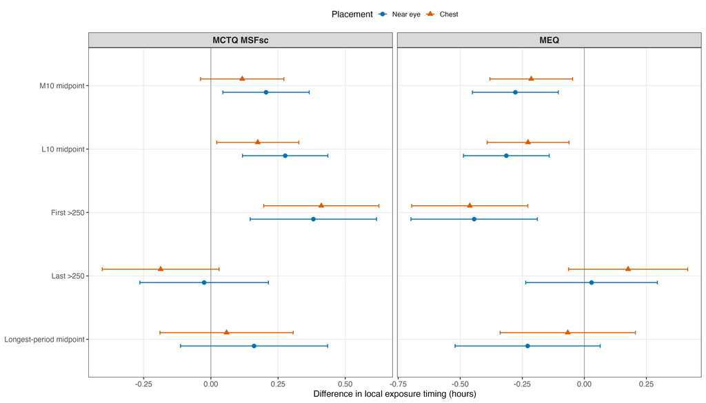

Figure 1: Site-adjusted associations of MCTQ MSFsc and MEQ with the five registered timing metrics. Near-eye measurements are primary and chest measurements complementary. Points are fitted effects and horizontal bars are 95% Wald confidence intervals.

Source data for the primary-effect figure.

# 5 Complementary chest results

Chest first-above-250 timing showed the same directional associations as the near-eye result for both instruments. Chest L10 was significant for MEQ but not after BH correction for MCTQ (`p = 0.022`, BH-adjusted `p = 0.055`). Chest M10 was significant for MEQ but not MCTQ. Last timing and longest-period midpoint remained inconclusive. These are complementary results and do not replace the near-eye evidence.

Complementary chest site-adjusted chronotype associations

MCTQ effects are per one-hour later MSFsc; MEQ effects are per 10 points greater morning preference

| Metric | Instrument | Effect (95% CI), hours | Raw p | BH-adjusted p | Interaction raw p | Interaction BH p | Participants / days / observations / derivation hours | Diagnostics |
| --- | --- | --- | --- | --- | --- | --- | --- | --- |
| M10 midpoint | MCTQ MSFsc | +0.117 (-0.038 to +0.272) | 0.130 | 0.162 | 0.216 | 0.360 | 153 / 896 / 896 / 20752.4 h | Acceptable |
| M10 midpoint | MEQ | -0.214 (-0.381 to -0.047) | **0.010** | **0.017** | 0.213 | 0.587 | 154 / 902 / 902 / 20891.8 h | Acceptable |
| L10 midpoint | MCTQ MSFsc | +0.174 (+0.022 to +0.327) | **0.022** | 0.055 | 0.071 | 0.353 | 153 / 896 / 896 / 20752.4 h | Acceptable |
| L10 midpoint | MEQ | -0.227 (-0.392 to -0.062) | **0.006** | **0.015** | 0.707 | 0.707 | 154 / 902 / 902 / 20891.8 h | Acceptable |
| First >250 | MCTQ MSFsc | +0.411 (+0.196 to +0.625) | **<0.001** | **<0.001** | 0.182 | 0.360 | 153 / 797 / 797 / 18518.4 h | Acceptable |
| First >250 | MEQ | -0.462 (-0.696 to -0.228) | **<0.001** | **<0.001** | 0.340 | 0.587 | 154 / 802 / 802 / 18634.7 h | Acceptable |
| Last >250 | MCTQ MSFsc | -0.187 (-0.404 to +0.031) | 0.084 | 0.140 | 0.843 | 0.843 | 153 / 783 / 783 / 18263.8 h | Acceptable |
| Last >250 | MEQ | +0.176 (-0.064 to +0.416) | 0.139 | 0.173 | 0.681 | 0.707 | 154 / 787 / 787 / 18358.1 h | Acceptable |
| Longest-period midpoint | MCTQ MSFsc | +0.058 (-0.189 to +0.306) | 0.608 | 0.608 | 0.607 | 0.759 | 149 / 547 / 547 / 12980.0 h | **Not acceptable** |
| Longest-period midpoint | MEQ | -0.067 (-0.339 to +0.206) | 0.607 | 0.607 | 0.352 | 0.587 | 150 / 549 / 549 / 13027.8 h | **Not acceptable** |

The placement hierarchy is fixed: near eye is primary and chest complementary. Placements were fitted separately.

# 6 Site interactions and descriptive trends

No site-by-MCTQ or site-by-MEQ interaction survived its five-outcome BH family at either placement. The smallest adjusted interaction p-value was 0.070 for the near-eye longest-period midpoint with MEQ; this remains above the fixed 0.05 rule. The chest longest-period/MEQ interaction model was singular in the ML comparison, so that interaction assessment is additionally not acceptable. The additive main-effect fit for that target was not singular. The same interaction form was singular in both paired-common longest-period/MEQ runs; the paired-placement display below uses the nonsingular additive M1 fits and does not interpret those interaction models.

Primary-dataset multiplicity audit

| Placement | Instrument | Comparison | Family | Registered / planned | Estimable raw p | Non-estimable | Independent BH check | Assessment |
| --- | --- | --- | --- | --- | --- | --- | --- | --- |
| Chest | MCTQ | Site interaction | H09-F3-MCTQ-interaction__primary__chest__all_available | 5 / 5 | 5 | 0 | Matches | Acceptable |
| Chest | MCTQ | Main association | H09-F1-MCTQ-main__primary__chest__all_available | 5 / 5 | 5 | 0 | Matches | Acceptable |
| Chest | MEQ | Site interaction | H09-F4-MEQ-interaction__primary__chest__all_available | 5 / 5 | 5 | 0 | Matches | Acceptable |
| Chest | MEQ | Main association | H09-F2-MEQ-main__primary__chest__all_available | 5 / 5 | 5 | 0 | Matches | Acceptable |
| Near eye | MCTQ | Site interaction | H09-F3-MCTQ-interaction__primary__glasses__all_available | 5 / 5 | 5 | 0 | Matches | Acceptable |
| Near eye | MCTQ | Main association | H09-F1-MCTQ-main__primary__glasses__all_available | 5 / 5 | 5 | 0 | Matches | Acceptable |
| Near eye | MEQ | Site interaction | H09-F4-MEQ-interaction__primary__glasses__all_available | 5 / 5 | 5 | 0 | Matches | Acceptable |
| Near eye | MEQ | Main association | H09-F2-MEQ-main__primary__glasses__all_available | 5 / 5 | 5 | 0 | Matches | Acceptable |

All registered rows remain in the family denominator. Every adjusted vector independently reproduces p.adjust(method = ‘BH’, n = 5).

Site-specific slopes are retained only as descriptive quantities. Across the primary registered targets, the complete site-specific output contains the submitted sites and 95% confidence intervals but no site-specific p-values or selective claims.

Descriptive site-specific slope ranges

| Placement | Metric | Instrument | Sites | Descriptive slope range, h |
| --- | --- | --- | --- | --- |
| Chest | M10 midpoint | MCTQ | 8 | -0.309 to +0.360 |
| Chest | M10 midpoint | MEQ | 8 | -0.713 to +0.126 |
| Chest | L10 midpoint | MCTQ | 8 | -0.426 to +0.491 |
| Chest | L10 midpoint | MEQ | 8 | -0.523 to +0.309 |
| Chest | First >250 | MCTQ | 8 | +0.023 to +0.840 |
| Chest | First >250 | MEQ | 8 | -1.016 to -0.065 |
| Chest | Last >250 | MCTQ | 8 | -0.919 to +0.084 |
| Chest | Last >250 | MEQ | 8 | -0.380 to +1.110 |
| Chest | Longest-period midpoint | MCTQ | 8 | -0.556 to +0.645 |
| Chest | Longest-period midpoint | MEQ | 8 | -0.664 to +0.668 |
| Near eye | M10 midpoint | MCTQ | 9 | -0.169 to +1.147 |
| Near eye | M10 midpoint | MEQ | 9 | -0.990 to +0.146 |
| Near eye | L10 midpoint | MCTQ | 9 | -0.032 to +0.815 |
| Near eye | L10 midpoint | MEQ | 9 | -0.521 to -0.091 |
| Near eye | First >250 | MCTQ | 9 | +0.050 to +1.242 |
| Near eye | First >250 | MEQ | 9 | -1.791 to +0.060 |
| Near eye | Last >250 | MCTQ | 9 | -1.253 to +0.492 |
| Near eye | Last >250 | MEQ | 9 | -1.217 to +0.774 |
| Near eye | Longest-period midpoint | MCTQ | 9 | -0.920 to +0.920 |
| Near eye | Longest-period midpoint | MEQ | 9 | -1.457 to +0.587 |

H09-F5 was not activated. Ranges describe fitted interaction-model components and are not site-specific inferential results.

# 7 Diagnostics and explicit acceptability

The diagnostic registry evaluates 16 domains for each of the 24 primary metric × instrument × placement targets. Eighteen targets are acceptable across all domains; six have at least one not-acceptable domain. A not-acceptable label records a specific limitation and is not silently converted into a pass because an estimate is statistically significant.

H09-002 distinguishes intentionally conservative quantitative screens from the final scientific assessment. The integrated registry screen flagged response/residual distribution for eight targets and residual heteroscedasticity for four targets. The lower-level all-threshold residual screen additionally flagged six outlier-only targets, for 14 distribution flags in that source artifact; those six had already been cleared by stable influence checks in the integrated screen. After inspecting the complete near-eye and chest panels in Figures 2 and 3, the author judged both domains acceptable for all targets. Both screen classifications, all thresholds, and the numeric evidence are retained in the residual diagnostic and author-adjudication artifacts.

Interpreted primary-dataset diagnostic registry

| Placement | Metric | Instrument | Participants / days / observations / derivation hours | Acceptable domains | Overall assessment | Not-acceptable domains |
| --- | --- | --- | --- | --- | --- | --- |
| Chest | M10 midpoint | MCTQ | 153 / 896 / 896 / 20752.4 h | 16 / 16 | Acceptable | — |
| Chest | M10 midpoint | MEQ | 154 / 902 / 902 / 20891.8 h | 16 / 16 | Acceptable | — |
| Chest | L10 midpoint | MCTQ | 153 / 896 / 896 / 20752.4 h | 16 / 16 | Acceptable | — |
| Chest | L10 midpoint | MEQ | 154 / 902 / 902 / 20891.8 h | 16 / 16 | Acceptable | — |
| Chest | First >250 | MCTQ | 153 / 797 / 797 / 18518.4 h | 16 / 16 | Acceptable | — |
| Chest | First >250 | MEQ | 154 / 802 / 802 / 18634.7 h | 16 / 16 | Acceptable | — |
| Chest | Last >250 | MCTQ | 153 / 783 / 783 / 18263.8 h | 16 / 16 | Acceptable | — |
| Chest | Last >250 | MEQ | 154 / 787 / 787 / 18358.1 h | 16 / 16 | Acceptable | — |
| Chest | Longest-period midpoint | MCTQ | 149 / 547 / 547 / 12980.0 h | 15 / 16 | **Not acceptable** | Prepared-data sensitivity |
| Chest | Longest-period midpoint | MEQ | 150 / 549 / 549 / 13027.8 h | 13 / 16 | **Not acceptable** | Convergence and Hessian \| Singularity and variance \| Prepared-data sensitivity |
| Chest | Mean >250 | MCTQ | 153 / 825 / 825 / 19196.8 h | 16 / 16 | Acceptable | — |
| Chest | Mean >250 | MEQ | 154 / 831 / 831 / 19336.1 h | 16 / 16 | Acceptable | — |
| Near eye | M10 midpoint | MCTQ | 140 / 810 / 810 / 18711.7 h | 16 / 16 | Acceptable | — |
| Near eye | M10 midpoint | MEQ | 141 / 816 / 816 / 18851.0 h | 16 / 16 | Acceptable | — |
| Near eye | L10 midpoint | MCTQ | 140 / 810 / 810 / 18711.7 h | 16 / 16 | Acceptable | — |
| Near eye | L10 midpoint | MEQ | 141 / 816 / 816 / 18851.0 h | 16 / 16 | Acceptable | — |
| Near eye | First >250 | MCTQ | 139 / 722 / 722 / 16716.3 h | 16 / 16 | Acceptable | — |
| Near eye | First >250 | MEQ | 140 / 727 / 727 / 16832.5 h | 16 / 16 | Acceptable | — |
| Near eye | Last >250 | MCTQ | 140 / 683 / 683 / 15900.8 h | 14 / 16 | **Not acceptable** | Participant influence \| Site influence |
| Near eye | Last >250 | MEQ | 141 / 687 / 687 / 15995.0 h | 14 / 16 | **Not acceptable** | Participant influence \| Site influence |
| Near eye | Longest-period midpoint | MCTQ | 131 / 478 / 478 / 11325.5 h | 15 / 16 | **Not acceptable** | Prepared-data sensitivity |
| Near eye | Longest-period midpoint | MEQ | 132 / 482 / 482 / 11419.8 h | 15 / 16 | **Not acceptable** | Prepared-data sensitivity |
| Near eye | Mean >250 | MCTQ | 140 / 736 / 736 / 17070.3 h | 16 / 16 | Acceptable | — |
| Near eye | Mean >250 | MEQ | 141 / 742 / 742 / 17209.6 h | 16 / 16 | Acceptable | — |

Every row has an explicit acceptable/not-acceptable decision. Distribution and heteroscedasticity use the H09-002 visual adjudication; the original quantitative screens remain linked below.

The main limitations are:

- The near-eye last-timing slopes are close to zero and change sign under some participant deletions and leave-one-site-out fits. No deletion changed a slope by the material 0.25-hour threshold, but the already-inconclusive direction is not stable.
- One of five declared fits for chest longest-period/MEQ—the ML interaction model—was singular; convergence/singularity is therefore not acceptable for that target. Fixed-effect matrices were full rank for all 540 fits and all Hessians were positive definite.
- The registered longest-period midpoint cannot be checked in the gap-timing-unaware artifact because that artifact contains neither the metric nor the endpoints required to reconstruct it. This makes the prepared-data-sensitivity domain not acceptable for all four longest-period placement/instrument targets.

Conversely, clock representation, chronotype linearity, temporal dependence, questionnaire/sample identity, site support, fixed-effect rank, paired/common sample identity, multiplicity, response/residual distribution, and residual heteroscedasticity were acceptable for all 24 targets. All participant-deletion refits completed; only the two near-eye last-timing targets failed the fixed direction-stability rule. Continuous-time AR(1) corrections changed slopes by at most 0.016 hours.

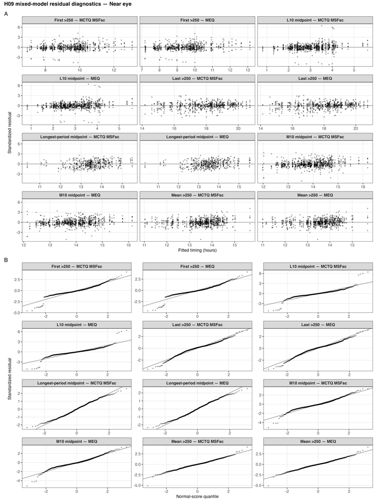

Figure 2: Near-eye residual-versus-fitted and normal-score Q-Q diagnostics for all six timing outcomes and both chronotype instruments. Under H09-002, visual inspection judged response/residual distribution and heteroscedasticity acceptable; the quantitative screen flags remain retained separately.

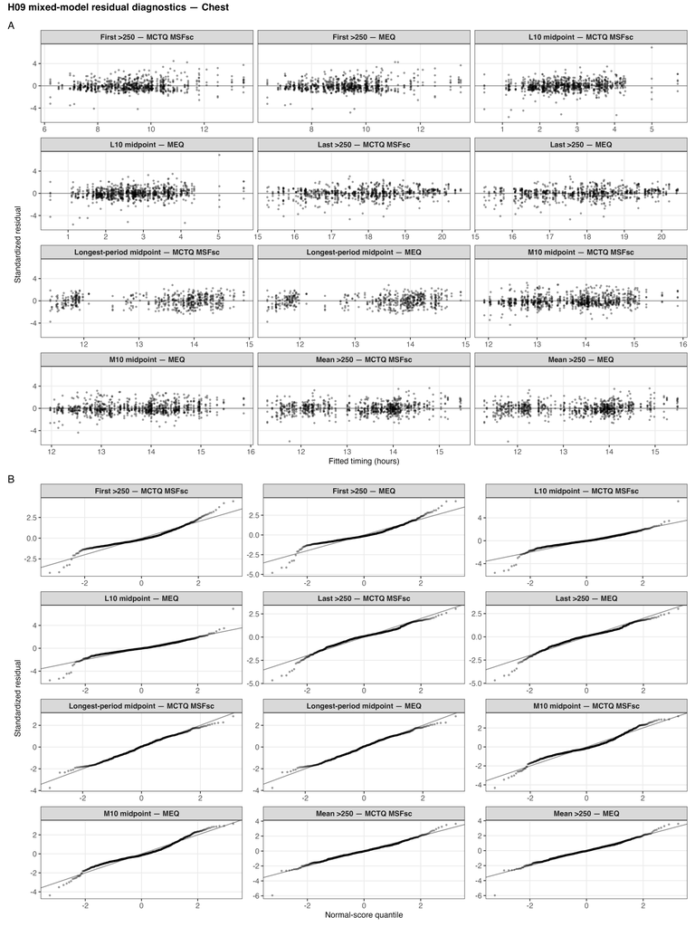

Figure 3: Chest residual-versus-fitted and normal-score Q-Q diagnostics for all six timing outcomes and both chronotype instruments. Under H09-002, visual inspection judged response/residual distribution and heteroscedasticity acceptable; the quantitative screen flags remain retained separately.

Source data for both diagnostic figures.

# 8 Placement-matched evidence

The paired-placement analysis fits near-eye and chest models separately on identical participant-day keys. Sample identity is exact for every metric and instrument. The display compares component estimates and component 95% confidence intervals; it does not estimate a between-placement difference interval because Stage 1 did not approve a joint covariance model. No equivalence margin was prespecified, so similarity is not equivalence.

Exact paired-placement estimates

| Metric | Instrument | Exact paired sample | Near-eye effect (95% CI), h | Chest effect (95% CI), h | Chest − near-eye point difference, h | Sample keys | Difference interval | Equivalence |
| --- | --- | --- | --- | --- | --- | --- | --- | --- |
| M10 midpoint | MCTQ MSFsc | 111 / 637 / 637 / 14734.8 h | +0.118 (-0.061 to +0.298) | +0.093 (-0.094 to +0.280) | -0.025 | Exact match | Not estimated | Not assessed |
| M10 midpoint | MEQ | 112 / 643 / 643 / 14874.1 h | -0.225 (-0.426 to -0.023) | -0.287 (-0.495 to -0.080) | -0.063 | Exact match | Not estimated | Not assessed |
| L10 midpoint | MCTQ MSFsc | 111 / 637 / 637 / 14734.8 h | +0.190 (+0.011 to +0.369) | +0.111 (-0.066 to +0.288) | -0.079 | Exact match | Not estimated | Not assessed |
| L10 midpoint | MEQ | 112 / 643 / 643 / 14874.1 h | -0.256 (-0.459 to -0.054) | -0.219 (-0.417 to -0.021) | +0.037 | Exact match | Not estimated | Not assessed |
| First >250 | MCTQ MSFsc | 111 / 558 / 558 / 12943.5 h | +0.329 (+0.080 to +0.579) | +0.353 (+0.099 to +0.607) | +0.024 | Exact match | Not estimated | Not assessed |
| First >250 | MEQ | 112 / 563 / 563 / 13059.7 h | -0.412 (-0.692 to -0.132) | -0.517 (-0.799 to -0.234) | -0.105 | Exact match | Not estimated | Not assessed |
| Last >250 | MCTQ MSFsc | 111 / 520 / 520 / 12131.8 h | -0.081 (-0.339 to +0.176) | -0.206 (-0.427 to +0.015) | -0.124 | Exact match | Not estimated | Not assessed |
| Last >250 | MEQ | 112 / 524 / 524 / 12226.1 h | +0.082 (-0.217 to +0.381) | +0.167 (-0.095 to +0.428) | +0.084 | Exact match | Not estimated | Not assessed |
| Longest-period midpoint | MCTQ MSFsc | 104 / 355 / 355 / 8428.9 h | +0.125 (-0.195 to +0.445) | +0.009 (-0.296 to +0.314) | -0.116 | Exact match | Not estimated | Not assessed |
| Longest-period midpoint | MEQ | 105 / 357 / 357 / 8476.7 h | -0.103 (-0.470 to +0.264) | -0.065 (-0.412 to +0.282) | +0.038 | Exact match | Not estimated | Not assessed |

Component intervals are not an interval for the chest-minus-near-eye difference. No equivalence claim is made.

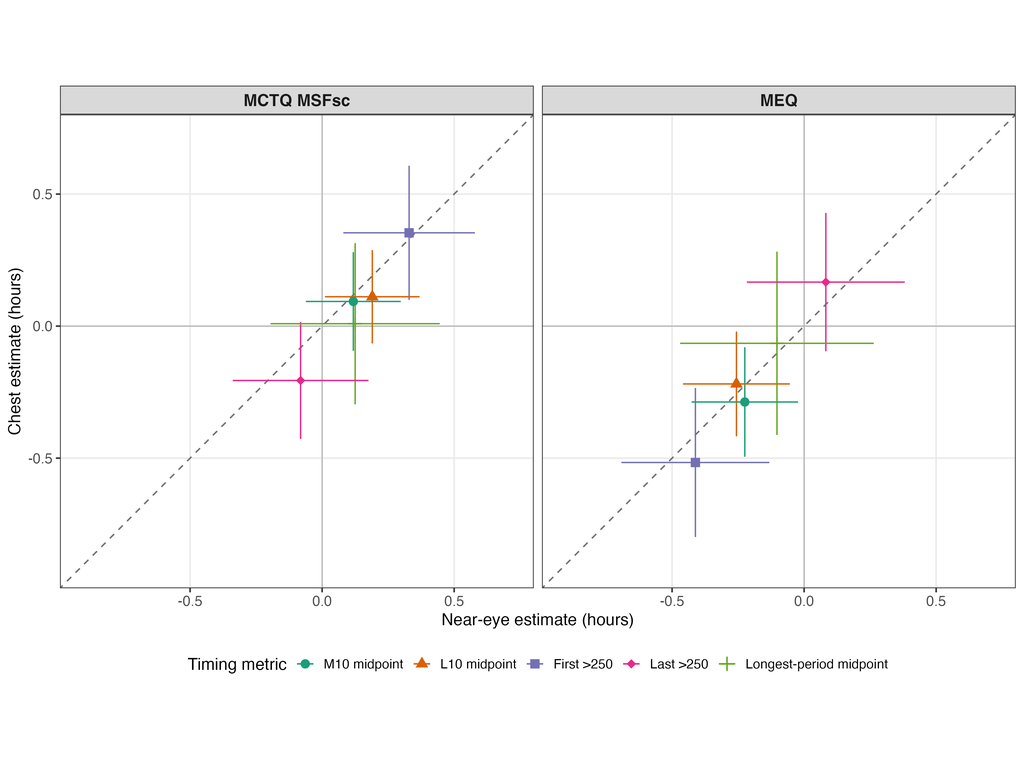

Figure 4: Near-eye and chest chronotype associations from separately fitted models using identical participant-day samples. Horizontal and vertical bars are the two component 95% confidence intervals; the diagonal is an identity reference, not an equivalence region.

Source data for the paired-placement figure.

# 9 Sensitivity findings

## 9.1 Gap-timing-unaware dataset

For the five outcomes available in both prepared datasets, exact common-key frames were created and fitted in addition to all-available frames. Most comparisons were stable within model uncertainty. Chest MCTQ L10 was precision-sensitive; chest MEQ mean timing was precision-sensitive in both all-available and common-sample comparisons; near-eye MEQ mean timing was precision-sensitive on the exact common sample. None of these changes creates an adjusted primary-family result because mean timing is outside F1–F4 and chest is complementary.

Primary versus gap-timing-unaware sensitivity

| Placement | Metric | Instrument | Primary all-available sample | Primary effect (95% CI), h | Gap all-available sample | Gap effect (95% CI), h | All-available stability | Exact common days | Common-sample stability |
| --- | --- | --- | --- | --- | --- | --- | --- | --- | --- |
| Chest | M10 midpoint | MCTQ MSFsc | 153 / 896 / 896 / 20752.4 h | +0.117 (-0.038 to +0.272) | 153 / 891 / 891 / NA h | +0.091 (-0.068 to +0.250) | Stable within model uncertainty | 888 | Stable within model uncertainty |
| Chest | M10 midpoint | MEQ | 154 / 902 / 902 / 20891.8 h | -0.214 (-0.381 to -0.047) | 154 / 897 / 897 / NA h | -0.182 (-0.353 to -0.011) | Stable within model uncertainty | 894 | Stable within model uncertainty |
| Chest | L10 midpoint | MCTQ MSFsc | 153 / 896 / 896 / 20752.4 h | +0.174 (+0.022 to +0.327) | 153 / 891 / 891 / NA h | +0.122 (-0.038 to +0.281) | Precision-sensitive | 888 | Precision-sensitive |
| Chest | L10 midpoint | MEQ | 154 / 902 / 902 / 20891.8 h | -0.227 (-0.392 to -0.062) | 154 / 897 / 897 / NA h | -0.187 (-0.360 to -0.015) | Stable within model uncertainty | 894 | Stable within model uncertainty |
| Chest | First >250 | MCTQ MSFsc | 153 / 797 / 797 / 18518.4 h | +0.411 (+0.196 to +0.625) | 153 / 861 / 861 / NA h | +0.389 (+0.176 to +0.601) | Stable within model uncertainty | 790 | Stable within model uncertainty |
| Chest | First >250 | MEQ | 154 / 802 / 802 / 18634.7 h | -0.462 (-0.696 to -0.228) | 154 / 867 / 867 / NA h | -0.468 (-0.696 to -0.239) | Stable within model uncertainty | 795 | Stable within model uncertainty |
| Chest | Last >250 | MCTQ MSFsc | 153 / 783 / 783 / 18263.8 h | -0.187 (-0.404 to +0.031) | 153 / 861 / 861 / NA h | -0.192 (-0.405 to +0.020) | Stable within model uncertainty | 780 | Stable within model uncertainty |
| Chest | Last >250 | MEQ | 154 / 787 / 787 / 18358.1 h | +0.176 (-0.064 to +0.416) | 154 / 867 / 867 / NA h | +0.164 (-0.071 to +0.399) | Stable within model uncertainty | 784 | Stable within model uncertainty |
| Chest | Longest-period midpoint | MCTQ MSFsc | 149 / 547 / 547 / 12980.0 h | +0.058 (-0.189 to +0.306) | Not estimable | Not estimable | Non-estimable | — | Non-estimable |
| Chest | Longest-period midpoint | MEQ | 150 / 549 / 549 / 13027.8 h | -0.067 (-0.339 to +0.206) | Not estimable | Not estimable | Non-estimable | — | Non-estimable |
| Chest | Mean >250 | MCTQ MSFsc | 153 / 825 / 825 / 19196.8 h | +0.108 (-0.037 to +0.254) | 153 / 861 / 861 / NA h | +0.128 (-0.012 to +0.268) | Stable within model uncertainty | 820 | Stable within model uncertainty |
| Chest | Mean >250 | MEQ | 154 / 831 / 831 / 19336.1 h | -0.138 (-0.296 to +0.021) | 154 / 867 / 867 / NA h | -0.172 (-0.323 to -0.020) | Precision-sensitive | 826 | Precision-sensitive |
| Near eye | M10 midpoint | MCTQ MSFsc | 140 / 810 / 810 / 18711.7 h | +0.205 (+0.045 to +0.366) | 140 / 805 / 805 / NA h | +0.183 (+0.016 to +0.349) | Stable within model uncertainty | 803 | Stable within model uncertainty |
| Near eye | M10 midpoint | MEQ | 141 / 816 / 816 / 18851.0 h | -0.278 (-0.451 to -0.105) | 141 / 811 / 811 / NA h | -0.247 (-0.427 to -0.068) | Stable within model uncertainty | 809 | Stable within model uncertainty |
| Near eye | L10 midpoint | MCTQ MSFsc | 140 / 810 / 810 / 18711.7 h | +0.276 (+0.118 to +0.435) | 140 / 805 / 805 / NA h | +0.283 (+0.111 to +0.454) | Stable within model uncertainty | 803 | Stable within model uncertainty |
| Near eye | L10 midpoint | MEQ | 141 / 816 / 816 / 18851.0 h | -0.314 (-0.487 to -0.142) | 141 / 811 / 811 / NA h | -0.290 (-0.478 to -0.102) | Stable within model uncertainty | 809 | Stable within model uncertainty |
| Near eye | First >250 | MCTQ MSFsc | 139 / 722 / 722 / 16716.3 h | +0.381 (+0.146 to +0.616) | 140 / 772 / 772 / NA h | +0.368 (+0.140 to +0.596) | Stable within model uncertainty | 715 | Stable within model uncertainty |
| Near eye | First >250 | MEQ | 140 / 727 / 727 / 16832.5 h | -0.444 (-0.699 to -0.189) | 141 / 778 / 778 / NA h | -0.449 (-0.694 to -0.204) | Stable within model uncertainty | 720 | Stable within model uncertainty |
| Near eye | Last >250 | MCTQ MSFsc | 140 / 683 / 683 / 15900.8 h | -0.025 (-0.264 to +0.214) | 140 / 772 / 772 / NA h | -0.025 (-0.261 to +0.211) | Stable within model uncertainty | 680 | Stable within model uncertainty |
| Near eye | Last >250 | MEQ | 141 / 687 / 687 / 15995.0 h | +0.029 (-0.236 to +0.294) | 141 / 778 / 778 / NA h | +0.012 (-0.247 to +0.271) | Stable within model uncertainty | 684 | Stable within model uncertainty |
| Near eye | Longest-period midpoint | MCTQ MSFsc | 131 / 478 / 478 / 11325.5 h | +0.161 (-0.113 to +0.434) | Not estimable | Not estimable | Non-estimable | — | Non-estimable |
| Near eye | Longest-period midpoint | MEQ | 132 / 482 / 482 / 11419.8 h | -0.228 (-0.521 to +0.064) | Not estimable | Not estimable | Non-estimable | — | Non-estimable |
| Near eye | Mean >250 | MCTQ MSFsc | 140 / 736 / 736 / 17070.3 h | +0.090 (-0.064 to +0.243) | 140 / 772 / 772 / NA h | +0.127 (-0.014 to +0.268) | Stable within model uncertainty | 731 | Stable within model uncertainty |
| Near eye | Mean >250 | MEQ | 141 / 742 / 742 / 17209.6 h | -0.169 (-0.334 to -0.003) | 141 / 778 / 778 / NA h | -0.166 (-0.317 to -0.015) | Stable within model uncertainty | 737 | Precision-sensitive |

Every reported common-sample comparison has identical participant-day keys. The registered longest-period midpoint is retained as explicitly non-estimable rather than substituted or imputed.

## 9.2 Photoperiod, participant weighting, temporal dependence, and L10 clock cut

Within-site-centred photoperiod adjustment was stable for 21 of 24 targets. Only the already near-zero near-eye last-timing slopes changed direction; the adapted chest MEQ mean-timing result was precision-sensitive. Equal-weight participant summaries were stable for 20 of 24 targets; directional changes again occurred only for near-zero last-timing or longest-period chest slopes. All 24 continuous-time AR(1) fits were stable. The strict `>16:00` and noon-cut L10 analyses differed by at most 0.037 hours and all four L10 clock-cut checks were acceptable.

Sensitivity classifications across 24 primary targets

| Sensitivity | Classification | Targets |
| --- | --- | --- |
| Continuous-time AR(1) | Stable within model uncertainty | 24 |
| Equal-weight participant summary | Direction-sensitive | 4 |
| Equal-weight participant summary | Stable within model uncertainty | 20 |
| Within-site photoperiod | Direction-sensitive | 2 |
| Within-site photoperiod | Precision-sensitive | 1 |
| Within-site photoperiod | Stable within model uncertainty | 21 |

## 9.3 Registered fifth outcome versus V0 mean timing

The registered exact-identifiable longest-period midpoint and V0 mean timing above 250 lx are different estimands and use different samples. The registered outcome is the fifth member of each primary family; mean timing remains a raw-p sensitivity only. The near-eye mean-timing MEQ raw p-value is 0.041, but it is not a registered-family finding and its diagnostic/sensitivity context does not justify replacing the preregistered outcome.

Registered longest-period midpoint and adapted mean timing

| Placement | Instrument | Outcome | Branch | Participants / days / observations / derivation hours | Effect (95% CI), h | Raw p | BH-adjusted p |
| --- | --- | --- | --- | --- | --- | --- | --- |
| Chest | MCTQ MSFsc | Midpoint of the longest continuous period above 250 lx melEDI | Registered fifth outcome | 149 / 547 / 547 / 12980.0 h | +0.058 (-0.189 to +0.306) | 0.608 | 0.608 |
| Chest | MCTQ MSFsc | Mean timing of exposure above 250 lx melEDI | Adapted V0 alternative | 153 / 825 / 825 / 19196.8 h | +0.108 (-0.037 to +0.254) | 0.133 | — (outside F1–F4) |
| Chest | MEQ | Midpoint of the longest continuous period above 250 lx melEDI | Registered fifth outcome | 150 / 549 / 549 / 13027.8 h | -0.067 (-0.339 to +0.206) | 0.607 | 0.607 |
| Chest | MEQ | Mean timing of exposure above 250 lx melEDI | Adapted V0 alternative | 154 / 831 / 831 / 19336.1 h | -0.138 (-0.296 to +0.021) | 0.080 | — (outside F1–F4) |
| Near eye | MCTQ MSFsc | Midpoint of the longest continuous period above 250 lx melEDI | Registered fifth outcome | 131 / 478 / 478 / 11325.5 h | +0.161 (-0.113 to +0.434) | 0.227 | 0.284 |
| Near eye | MCTQ MSFsc | Mean timing of exposure above 250 lx melEDI | Adapted V0 alternative | 140 / 736 / 736 / 17070.3 h | +0.090 (-0.064 to +0.243) | 0.240 | — (outside F1–F4) |
| Near eye | MEQ | Midpoint of the longest continuous period above 250 lx melEDI | Registered fifth outcome | 132 / 482 / 482 / 11419.8 h | -0.228 (-0.521 to +0.064) | 0.108 | 0.135 |
| Near eye | MEQ | Mean timing of exposure above 250 lx melEDI | Adapted V0 alternative | 141 / 742 / 742 / 17209.6 h | -0.169 (-0.334 to -0.003) | **0.041** | — (outside F1–F4) |

Rows are separate estimands and samples. Differences are descriptive, not a robustness test of a common outcome.

# 10 V0 reconstruction and reconciliation

Exact V0 reproduction and audited MCTQ comparison

| Placement | Metric | V0 sample: participants / days | V0 MCTQ effect (95% CI), h | V0 raw p | V0 scalar adjusted display | Audited sample: participants / days | Audited MCTQ effect (95% CI), h | Audited BH p | Audited − V0 effect, h |
| --- | --- | --- | --- | --- | --- | --- | --- | --- | --- |
| Chest | M10 midpoint | 153 / 891 | +0.313 (+0.173 to +0.454) | **<0.001** | <0.001 | 153 / 896 | +0.117 (-0.038 to +0.272) | 0.162 | -0.196 |
| Chest | L10 midpoint | 153 / 891 | +0.320 (+0.191 to +0.449) | **<0.001** | <0.001 | 153 / 896 | +0.174 (+0.022 to +0.327) | 0.055 | -0.145 |
| Chest | First >250 | 153 / 861 | +0.573 (+0.389 to +0.757) | **<0.001** | <0.001 | 153 / 797 | +0.411 (+0.196 to +0.625) | **<0.001** | -0.162 |
| Chest | Last >250 | 153 / 861 | +0.127 (-0.069 to +0.323) | 0.201 | 1.000 | 153 / 783 | -0.187 (-0.404 to +0.031) | 0.140 | -0.314 |
| Chest | Mean >250 | 153 / 861 | +0.385 (+0.243 to +0.528) | **<0.001** | <0.001 | 153 / 825 | +0.108 (-0.037 to +0.254) | — (adapted mean) | -0.277 |
| Near eye | M10 midpoint | 140 / 805 | +0.308 (+0.175 to +0.440) | **<0.001** | <0.001 | 140 / 810 | +0.205 (+0.045 to +0.366) | **0.017** | -0.102 |
| Near eye | L10 midpoint | 140 / 805 | +0.399 (+0.266 to +0.532) | **<0.001** | <0.001 | 140 / 810 | +0.276 (+0.118 to +0.435) | **0.003** | -0.123 |
| Near eye | First >250 | 140 / 772 | +0.443 (+0.263 to +0.623) | **<0.001** | <0.001 | 139 / 722 | +0.381 (+0.146 to +0.616) | **0.003** | -0.062 |
| Near eye | Last >250 | 140 / 772 | +0.256 (+0.032 to +0.479) | **0.025** | 0.125 | 140 / 683 | -0.025 (-0.264 to +0.214) | 0.811 | -0.281 |
| Near eye | Mean >250 | 140 / 772 | +0.323 (+0.194 to +0.452) | **<0.001** | <0.001 | 140 / 736 | +0.090 (-0.064 to +0.243) | — (adapted mean) | -0.234 |

V0 scalar-adjusted values are shown only to reproduce the legacy calculation; they are not accepted BH family results. V0 and audited effects differ in model, prepared data, and for some outcomes sample.

The recreated V0 figures retain all five V0 outcomes rather than repeating the original result-dependent omission of last timing. Their black lines faithfully reproduce the pooled ordinary-`lm` display and are labelled as not representing the mixed models. Site labels, ordering, and colours are corrected to the submitted-manuscript registry. The audited mixed-model effects are shown in the primary forest plot above.

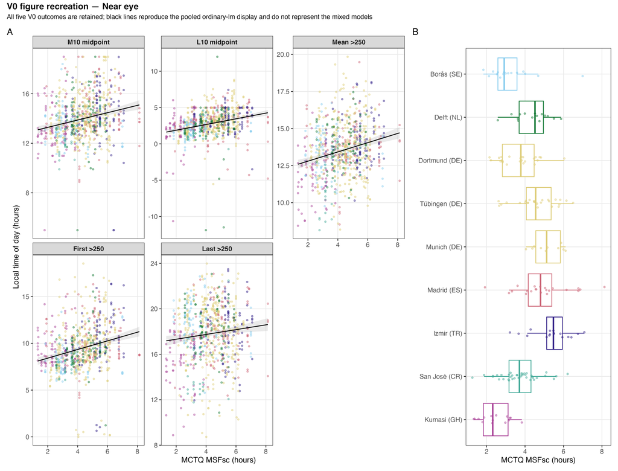

Figure 5: Near-eye V0 figure recreation. All five V0 outcomes are retained. Black pooled ordinary-regression lines reproduce the legacy visual but do not represent the audited mixed models; the right panel shows MCTQ MSFsc by submitted-manuscript site.

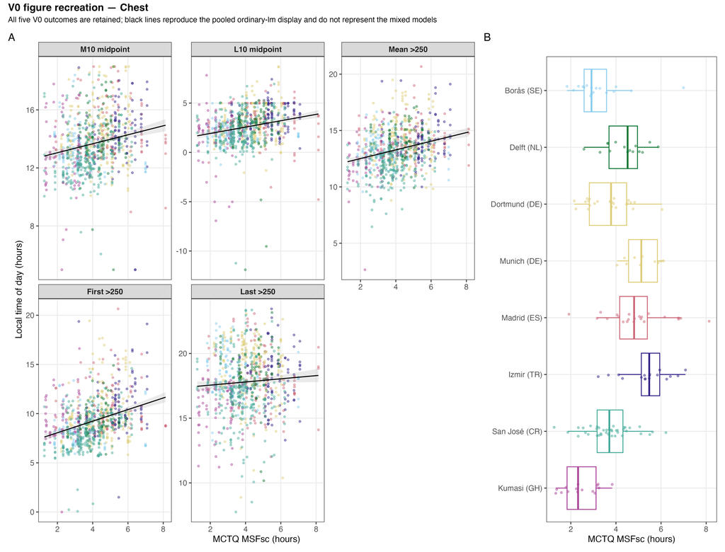

Figure 6: Chest V0 figure recreation with all five legacy outcomes and corrected submitted-manuscript site display.

Observed source data for both V0 figures and pooled line coordinates.

# 11 Reproducibility and artifact map

The H09 runner verified 16 pinned input identities, created 108 immutable model frames, stored 540 fitted model objects, and evaluated 24 primary diagnostic targets under R 4.6.1 and the project library. All durable figures have paired source CSVs and both PNG and PDF exports. Final-size QA used the established export scaling rule; effective essential text is at least 5.10 points at a 170-mm display width.

Consequential package versions

R 4.6.1; 108 frames; 540 stored model objects; 0 resampling replicates

| Package | Version |
| --- | --- |
| dplyr | 1.2.1 |
| tidyr | 1.3.2 |
| purrr | 1.2.2 |
| tibble | 3.3.1 |
| readr | 2.2.0 |
| digest | 0.6.39 |
| openssl | 2.4.2 |
| lme4 | 2.0.1 |
| nlme | 3.1.168 |
| emmeans | 2.0.3 |
| ggplot2 | 4.0.3 |
| patchwork | 1.3.2 |
| ragg | 1.5.2 |
| gt | 1.3.0 |
| scales | 1.4.0 |
| rvest | 1.0.5 |

Durable audit links:

- Complete model results
- Complete main and interaction tests
- Complete diagnostic assessment registry
- Author diagnostic adjudication and retained numeric screens
- Participant influence summary
- Leave-one-site-out summary
- Gap-timing-unaware sensitivity
- Figure manifest, physical-size metadata, QA, and alt text
- Artifact checksums

The declared shared preparation qualification remains unchanged: PREP-003/FIND-044 remain open: current metric, MDER, and state-support values have not all passed a current-manifest independent reconstruction. It is neither repaired nor hidden by this H09-owned analysis.

# 12 Stage 2 disposition and reader-report authorization

**ImportantH09-002 — approved as amended on 2026-08-10**

The author accepted all result gates and authorized the standalone reader report, with one diagnostic amendment: visual inspection of Figures 2 and 3 supports an **acceptable** final assessment for response/residual distribution and residual heteroscedasticity. The integrated quantitative heuristic still records eight distribution flags and four heteroscedasticity flags, while the lower-level all-threshold file retains 14 distribution flags; both are preserved as audit evidence rather than treated as the final verdict. This amendment does not alter any fitted model, sample, estimate, 95% confidence interval, p-value, multiplicity decision, sensitivity result, or the six targets that remain not acceptable because of influence, convergence/singularity, or the unavailable registered longest-period gap sensitivity.